# Introduction: Level Analytics for Job Descriptions

In this notebook, I will demonstrate how to determine the level info from unstructure text feature data by using two approaches:

- Approach 1 - Dense Neural Network (DNN)
- Approach 2 - Convolutional Neural Network (DNN)

For approach 1, I will use NLTK and gensim word2vec to do text feature engineering, then use scikit-learn multi-class dense neural network classifier to train a classification model.

For approach 2, I will use tensorflow & keras Convolutional Neural Network to train a several layers classification model including embedding, convolution, pooling, dropout and final dense output layers.

## Dataset

The dataset is a historical data of job descriptions stored as "job_descriptions.csv" file.

## Python Library

```python
# import future compatible function so that we can have consistent python 3 function outputs
from __future__ import division, print_function
# Pandas and numpy for converting from Spark dataframe into Pandas dataframe
import pandas as pd
import numpy as np
# Make the random numbers predictable
np.random.seed(42)
# allow ML models training processes with parallism
import multiprocessing
# get the number of available CPU cores for parallel processing
cpu_count = multiprocessing.cpu_count()

# import os
import collections
# import re
import string
```

```python
# Allow multiple output/display from one cell
from IPython.core.interactiveshell import InteractiveShell
InteractiveShell.ast_node_interactivity = "all"
```

```python
# Load NLP and Word2Vec libraries
from gensim.models import Word2Vec
from gensim import models
import ssl
try:
    _create_unverified_https_context = ssl._create_unverified_context
except AttributeError:
    pass
else:
    ssl._create_default_https_context = _create_unverified_https_context
import nltk
# Stop Word Removal
from nltk.corpus import stopwords
# from nltk.tokenize import word_tokenize
from nltk.stem import WordNetLemmatizer
from nltk.corpus import wordnet
```

```python
# Load SKLearn library for standard ML processes
from sklearn.neural_network import MLPClassifier
from sklearn.preprocessing import StandardScaler, OneHotEncoder, LabelEncoder
from sklearn.compose import ColumnTransformer
from sklearn.pipeline import Pipeline
from sklearn.impute import SimpleImputer
from sklearn.model_selection import train_test_split
import joblib
from sklearn.metrics import accuracy_score, classification_report
```

```python
# Load tensorflow and keras
from tensorflow.keras.callbacks import ModelCheckpoint
from tensorflow.keras.layers import Dense, Dropout, Reshape, Flatten, concatenate, Input, Conv1D, GlobalMaxPooling1D, Embedding
from keras.layers.recurrent import LSTM
from tensorflow.keras.models import Sequential
from tensorflow.keras.preprocessing.text import Tokenizer
from tensorflow.keras.preprocessing.sequence import pad_sequences
from tensorflow.keras.models import Model, load_model
```

```python
nltk.download("stopwords")
nltk.download('wordnet')
nltk.download('omw')
nltk.download('punkt')
```

```
True
```

```
True
```

```
True
```

```
True
```

# Data Set Loading and Cleaning Up

## Load Job Description CSV Data

```python
tmp_df = pd.read_csv('./job_descriptions.csv', header='infer')
tmp_df.info()
```

## Clean Up

```python
# remove any rows without job_description and this may change the index order
tmp_df.dropna(inplace=True)
# need to reset the index since the index will be used to concat the tables
tmp_df = tmp_df.reset_index(drop=True)
# check if index is reset
tmp_df.info()
tmp_df.head()
tmp_df.tail()
```

```python
# Combine simply job description and title so that job title is a part of job description
tmp_df['job_description'] = tmp_df['job_title'] + " " + tmp_df['job_description']
```

```python
# Prepare final data set for next step of text feature engineering
tmp_df = tmp_df[['req_guid', 'hcs', 'level', 'job_title', 'job_description']]
```

```python
tmp_df.info()
tmp_df.head()
tmp_df.tail()
```

```python
# copy the clean dataset for two different approaches
df = tmp_df
cf = tmp_df
```

# Approach 1 - Dense Neural Network

For this approach, raw text data will be transformed into feature vectors and then those vectors will be fed into a dense neural network model for training. I will implement the following feature vectorization steps in order to obtain relevant features from the dataset.

- Tokenizing
- Remove stop words
- Lemmatization (not stem since stemming can reduce the interpretability)
- Word Embeddings as features

## Tokenization

Tokenization is the process by dividing the quantity of text into smaller parts called tokens so that each token can be further treated for machine learning purposes. A token can be a character, a word, a sentence or a paragraph. In this notebook, I only consider words as tokens.

I can use NLTK word_tokenize function to process the job description field (by removing punctuations and separating words) like below

```
df['job_description'] = df.apply(lambda row: word_tokenize(row.job_description), axis=1)
```

Or I can just use python string split function to separate text since the job description has been cleaned as below.

```python
# Tokenize the job description and title
df['job_description'] = df["job_description"].str.lower()
df['job_description'] = df["job_description"].str.split(" ")
```

```python
df.head()
```

## Stopword Removal

A stop word is a commonly used word (such as “the”, “a”, “an”, “in”) that a NLP program has been programmed to ignore. In this notebook, I will use NLTK stop words dataset to remove any stop words in job description field.

```python
# Get stopwords list from NLTK library
stop_words = stopwords.words('english')
# Define a function to remove any stop words from input text
def removeStopWords(x):
        return [w.lower() for w in x if (w not in stop_words) and (w != '') and (w is not None)]
# Apply the defined function to remove stop words for job descriptions
df['job_description'] = df.apply(lambda row: removeStopWords(row.job_description), axis=1)
# Show some results
df.head()
```

## Lemmatization

Lemmatisation (or lemmatization) in linguistics is the process of grouping together the inflected forms of a word so they can be analysed as a single item, identified by the word's lemma, or dictionary form. For example, in English, the verb 'to walk' may appear as 'walk', 'walked', 'walks', 'walking'. The base form, 'walk', that one might look up in a dictionary, is called the lemma for the word. I will use NLTK lemmatization function to convert words into their lemma.

```python
# Define lemmatization function by using NLTK WordNetLemmatizer function
def lemma(x):
    lemmatizer = WordNetLemmatizer()
    return [lemmatizer.lemmatize(w.lower(), pos='v') for w in x if (w != '') and (w is not None)]
# Apply the defined function to process job descriptions
df['job_description'] = df.apply(lambda row: lemma(row.job_description), axis=1)
# Show some results
df.head()
```

## Word Embedding Vectors with Gensim

A word embedding is a form of representing words and documents using a dense vector representation. The position of a word within the vector space is learned from text and is based on the words that surround the word when it is used. Word embeddings can be trained using the input texts. One can read more about word embeddings [here](https://www.analyticsvidhya.com/blog/2017/06/word-embeddings-count-word2veec/) and [here](https://jalammar.github.io/illustrated-word2vec/).

In this notebook, I am going to use gensim library Word2Vec functionality to generate word embedding vectors so that I can use those vectors later on to train the classification model.

### Word2Vec Mean Vector

Gensim Word2Vec will generate a vector (dimension of 300 here) for each word after training based on all job descriptions. So, I will define a function to get average (mean) vectors for a job description.

In this project, I will use the pre-train word2vec model which pre-trained on 2.5 million job descriptions.

```python
# Load the pre-trained model
word2vec_path = './nnc_word2vec.bin'
model_w2v = Word2Vec.load(word2vec_path)
print(model_w2v)
```

```
Word2Vec(vocab=381161, size=300, alpha=0.025)
```

```python
# Define a function to get average (mean) vectors for a job description based on trained word2vec model
def get_mean_vectors(words):
    # remove out of vocabulary words
    words = [word for word in words if word in model_w2v.wv.vocab]
    if len(words) >= 1:
        return np.mean(model_w2v[words], axis=0)
    else:
        return []
```

```python
# Apply the function to generate 300 dimension vectors for each job description in the data set
df['job_description_vectors'] = df.apply(lambda row: get_mean_vectors(row.job_description), axis=1)
# Show some sample results
df.head()
```

### Covert Vectors into Columns

Here, I am going to convert job description vectors into columns so that I can easily generate training and testing data.

```python
# Put job description vectors as columns
series = df['job_description_vectors'].apply(lambda x : np.array(x)).values.reshape(-1,1)
w2v = np.apply_along_axis(lambda x : x[0], 1, series)
w2v_df = pd.DataFrame(w2v)
tmp_df = pd.concat([df, w2v_df], axis=1)
```

```python
tmp_df.head()
```

```python
# Name label field so that the classification model knows which field is the target (label) one
tmp_df.rename(columns={'level':'label'}, inplace=True)
# Prepare final data table by removing unuseful columns
tmp_df.drop(columns=['req_guid','job_title', 'job_description', 'job_description_vectors'], inplace=True)
```

```python
# Remove any NULL or blank rows
tmp_df.dropna(inplace=True)
```

```python
# Show some sample results
tmp_df.head()
```

|  | hcs | label | 0 | 1 | 2 | 3 | 4 | 5 | 6 | 7 | ... | 290 | 291 | 292 | 293 | 294 | 295 | 296 | 297 | 298 | 299 |
| --- | --- | --- | --- | --- | --- | --- | --- | --- | --- | --- | --- | --- | --- | --- | --- | --- | --- | --- | --- | --- | --- |
| 0 | 15-310 | 0 | -0.524481 | 0.235411 | -0.132670 | -0.020337 | 0.312904 | 0.221908 | -0.736390 | 0.181258 | ... | 0.321223 | -0.066776 | -0.610478 | 0.139781 | -0.129489 | 0.140652 | -0.397740 | 0.115472 | -0.272955 | -0.171184 |
| 1 | 15-140 | 0 | 0.598488 | 0.049583 | -0.327377 | 0.282883 | 0.039323 | 0.172630 | -0.149684 | 0.115693 | ... | 0.251436 | 0.610577 | 0.077503 | 0.485886 | 0.136543 | 0.190457 | -0.509649 | 0.075749 | -0.102336 | 0.787568 |
| 2 | 15-150 | 3 | -0.087504 | -0.437537 | -0.307802 | 0.110578 | 0.066642 | -0.282548 | -0.201437 | 0.149702 | ... | 0.222576 | -0.371889 | 0.083847 | 0.188790 | -0.185239 | -0.292886 | -0.742442 | 0.320284 | -0.095822 | 0.141854 |
| 3 | 15-140 | 0 | -0.140149 | 0.509686 | -0.749764 | 0.107491 | 0.116810 | -0.548908 | -0.984254 | -0.544031 | ... | 0.444285 | 0.864403 | -0.693706 | -0.100372 | 0.123468 | 0.631279 | -0.482237 | 0.037572 | 0.267925 | 0.322544 |
| 4 | 15-190 | 3 | -0.414757 | 0.213738 | -0.146151 | 0.378821 | 0.698331 | 0.100321 | -0.103432 | 0.216767 | ... | -0.539613 | 0.602877 | -0.304115 | 0.131448 | 0.423423 | -0.168812 | -0.293884 | -0.679063 | -0.028404 | -0.386099 |

5 rows × 302 columns

## Encoding for Categorical Fields

```python
# One Hot Encoding for hcs
tmp_hcs = tmp_df[['hcs']]

tmp_hcs = pd.get_dummies(tmp_hcs, columns=['hcs'], prefix=['hcs'])

tmp_hcs.head()
```

|  | hcs_15-100 | hcs_15-120 | hcs_15-140 | hcs_15-150 | hcs_15-160 | hcs_15-170 | hcs_15-180 | hcs_15-190 | hcs_15-230 | hcs_15-260 | ... | hcs_15-330 | hcs_15-340 | hcs_15-350 | hcs_15-360 | hcs_15-370 | hcs_15-380 | hcs_15-400 | hcs_15-500 | hcs_15-520 | hcs_15-550 |
| --- | --- | --- | --- | --- | --- | --- | --- | --- | --- | --- | --- | --- | --- | --- | --- | --- | --- | --- | --- | --- | --- |
| 0 | 0 | 0 | 0 | 0 | 0 | 0 | 0 | 0 | 0 | 0 | ... | 0 | 0 | 0 | 0 | 0 | 0 | 0 | 0 | 0 | 0 |
| 1 | 0 | 0 | 1 | 0 | 0 | 0 | 0 | 0 | 0 | 0 | ... | 0 | 0 | 0 | 0 | 0 | 0 | 0 | 0 | 0 | 0 |
| 2 | 0 | 0 | 0 | 1 | 0 | 0 | 0 | 0 | 0 | 0 | ... | 0 | 0 | 0 | 0 | 0 | 0 | 0 | 0 | 0 | 0 |
| 3 | 0 | 0 | 1 | 0 | 0 | 0 | 0 | 0 | 0 | 0 | ... | 0 | 0 | 0 | 0 | 0 | 0 | 0 | 0 | 0 | 0 |
| 4 | 0 | 0 | 0 | 0 | 0 | 0 | 0 | 1 | 0 | 0 | ... | 0 | 0 | 0 | 0 | 0 | 0 | 0 | 0 | 0 | 0 |

5 rows × 25 columns

```python
# final_df = pd.concat([tmp_df, tmp_industry, tmp_market, tmp_opco, tmp_hcs], axis=1)
final_df = pd.concat([tmp_df, tmp_hcs], axis=1)
final_df.head()
final_df.info()
```

|  | hcs | label | 0 | 1 | 2 | 3 | 4 | 5 | 6 | 7 | ... | hcs_15-330 | hcs_15-340 | hcs_15-350 | hcs_15-360 | hcs_15-370 | hcs_15-380 | hcs_15-400 | hcs_15-500 | hcs_15-520 | hcs_15-550 |
| --- | --- | --- | --- | --- | --- | --- | --- | --- | --- | --- | --- | --- | --- | --- | --- | --- | --- | --- | --- | --- | --- |
| 0 | 15-310 | 0 | -0.524481 | 0.235411 | -0.132670 | -0.020337 | 0.312904 | 0.221908 | -0.736390 | 0.181258 | ... | 0 | 0 | 0 | 0 | 0 | 0 | 0 | 0 | 0 | 0 |
| 1 | 15-140 | 0 | 0.598488 | 0.049583 | -0.327377 | 0.282883 | 0.039323 | 0.172630 | -0.149684 | 0.115693 | ... | 0 | 0 | 0 | 0 | 0 | 0 | 0 | 0 | 0 | 0 |
| 2 | 15-150 | 3 | -0.087504 | -0.437537 | -0.307802 | 0.110578 | 0.066642 | -0.282548 | -0.201437 | 0.149702 | ... | 0 | 0 | 0 | 0 | 0 | 0 | 0 | 0 | 0 | 0 |
| 3 | 15-140 | 0 | -0.140149 | 0.509686 | -0.749764 | 0.107491 | 0.116810 | -0.548908 | -0.984254 | -0.544031 | ... | 0 | 0 | 0 | 0 | 0 | 0 | 0 | 0 | 0 | 0 |
| 4 | 15-190 | 3 | -0.414757 | 0.213738 | -0.146151 | 0.378821 | 0.698331 | 0.100321 | -0.103432 | 0.216767 | ... | 0 | 0 | 0 | 0 | 0 | 0 | 0 | 0 | 0 | 0 |

5 rows × 327 columns

```
<class 'pandas.core.frame.DataFrame'>
Int64Index: 2206 entries, 0 to 2205
Columns: 327 entries, hcs to hcs_15-550
dtypes: float32(300), int64(1), object(1), uint8(25)
memory usage: 2.6+ MB
```

```python
# Prepare final data table by removing unuseful columns
final_df.drop(columns=['hcs'], inplace=True)
final_df.head()
```

|  | label | 0 | 1 | 2 | 3 | 4 | 5 | 6 | 7 | 8 | ... | hcs_15-330 | hcs_15-340 | hcs_15-350 | hcs_15-360 | hcs_15-370 | hcs_15-380 | hcs_15-400 | hcs_15-500 | hcs_15-520 | hcs_15-550 |
| --- | --- | --- | --- | --- | --- | --- | --- | --- | --- | --- | --- | --- | --- | --- | --- | --- | --- | --- | --- | --- | --- |
| 0 | 0 | -0.524481 | 0.235411 | -0.132670 | -0.020337 | 0.312904 | 0.221908 | -0.736390 | 0.181258 | 0.084478 | ... | 0 | 0 | 0 | 0 | 0 | 0 | 0 | 0 | 0 | 0 |
| 1 | 0 | 0.598488 | 0.049583 | -0.327377 | 0.282883 | 0.039323 | 0.172630 | -0.149684 | 0.115693 | 1.559744 | ... | 0 | 0 | 0 | 0 | 0 | 0 | 0 | 0 | 0 | 0 |
| 2 | 3 | -0.087504 | -0.437537 | -0.307802 | 0.110578 | 0.066642 | -0.282548 | -0.201437 | 0.149702 | 0.960544 | ... | 0 | 0 | 0 | 0 | 0 | 0 | 0 | 0 | 0 | 0 |
| 3 | 0 | -0.140149 | 0.509686 | -0.749764 | 0.107491 | 0.116810 | -0.548908 | -0.984254 | -0.544031 | 1.041327 | ... | 0 | 0 | 0 | 0 | 0 | 0 | 0 | 0 | 0 | 0 |
| 4 | 3 | -0.414757 | 0.213738 | -0.146151 | 0.378821 | 0.698331 | 0.100321 | -0.103432 | 0.216767 | 0.517812 | ... | 0 | 0 | 0 | 0 | 0 | 0 | 0 | 0 | 0 | 0 |

5 rows × 326 columns

## Data Preparation for Training and Testing

```python
# Get numpy array on feature set X and target set y
X = np.array(final_df.drop(columns=['label']))

y = np.array(final_df['label'])
```

```python
# Double check their shape
X.shape
y.shape
```

```
(2206, 325)
```

```
(2206,)
```

## Standard Scaling

Standardization of a dataset is a common requirement for many machine learning estimators: they might behave badly if the individual features do not more or less look like standard normally distributed data (e.g. neural network classifier). People usually can standardize features by removing the mean and scaling to unit variance. In this notebook, I will use StandardScaler function to do that.

```python
# standardize the vectors
X = StandardScaler().fit_transform(X)
X
```

```
array([[-1.0506618 ,  0.8399727 ,  0.01206612, ..., -0.16432244,
        -0.3122698 , -0.109209  ],
       [ 1.7421954 ,  0.16155341, -0.6131564 , ..., -0.16432244,
        -0.3122698 , -0.109209  ],
       [ 0.03611369, -1.6168193 , -0.55029935, ..., -0.16432244,
        -0.3122698 , -0.109209  ],
       ...,
       [-0.6439116 , -1.0712377 ,  0.2085332 , ..., -0.16432244,
        -0.3122698 , -0.109209  ],
       [-2.49217   , -0.8277163 , -0.2865029 , ..., -0.16432244,
        -0.3122698 , -0.109209  ],
       [-0.5274671 ,  0.20741142,  1.273207  , ..., -0.16432244,
        -0.3122698 , -0.109209  ]], dtype=float32)
```

```python
y
```

```
array([0, 0, 3, ..., 3, 1, 3], dtype=int64)
```

## Data Splits for Training and Testing

```python
X_train, X_test, y_train, y_test = train_test_split(X, y, test_size=.2, random_state=42, stratify=y, shuffle=True)

print(len(X_train))
print(len(X_test))
```

```
1764
442
```

## Neural Network Multi-class Classifier Training

```python
# Define a neural netowork multi-class classifier model
# Two hidden layers are set to 300 and 200
# Activation function is set to relu
# Solver (optimizer) function is set to adam for faster converge and better performance (lbfgs solver/optimizer causes overfitting)
# Early_stopping is set to true to prevent overfitting
# Learning rate is set to adaptive, which means it will automatically adjust from initial rate during each iteration
# Alpha is set to 0.01 so that some degree of overfitting can be prevented
# Batch_size is set to 128 so that 128 training data instances are used for calculation gradient descent
# Random_state is set to 42, consistant with initial setup
# Verbose is set to true to display information for all iterations
est = MLPClassifier(activation='relu', \
                    hidden_layer_sizes=(300, 200),\
                    solver='adam',\
                    learning_rate='adaptive',\
                    max_iter=500,\
                    learning_rate_init=0.001,\
                    batch_size=128,\
                    tol=0.000001,\
                    random_state=42,\
                    early_stopping=True,\
                    verbose=True,\
                    alpha=0.01)
```

```python
print("Training Neural Network MLP-Classifier...")
nnc = est.fit(X_train, y_train)
print(nnc)
```

```
Training Neural Network MLP-Classifier...
Iteration 1, loss = 1.27228024
Validation score: 0.610169
Iteration 2, loss = 0.84268881
Validation score: 0.689266
Iteration 3, loss = 0.71445011
Validation score: 0.711864
Iteration 4, loss = 0.60583190
Validation score: 0.700565
Iteration 5, loss = 0.52904519
Validation score: 0.689266
Iteration 6, loss = 0.46106658
Validation score: 0.711864
Iteration 7, loss = 0.39564856
Validation score: 0.706215
Iteration 8, loss = 0.33067513
Validation score: 0.740113
Iteration 9, loss = 0.28320520
Validation score: 0.728814
Iteration 10, loss = 0.23509378
Validation score: 0.728814
Iteration 11, loss = 0.20694371
Validation score: 0.723164
Iteration 12, loss = 0.17141769
Validation score: 0.723164
Iteration 13, loss = 0.14296027
Validation score: 0.740113
Iteration 14, loss = 0.13097110
Validation score: 0.723164
Iteration 15, loss = 0.11257493
Validation score: 0.734463
Iteration 16, loss = 0.10963767
Validation score: 0.745763
Iteration 17, loss = 0.10495585
Validation score: 0.745763
Iteration 18, loss = 0.09419113
Validation score: 0.717514
Iteration 19, loss = 0.09472739
Validation score: 0.728814
Iteration 20, loss = 0.08344879
```

[output cut: 41 more lines]

```
Iteration 41, loss = 0.06205010
Validation score: 0.734463
Iteration 42, loss = 0.05169427
Validation score: 0.745763
Iteration 43, loss = 0.06197738
Validation score: 0.723164
Validation score did not improve more than tol=0.000001 for 10 consecutive epochs. Stopping.
MLPClassifier(activation='relu', alpha=0.01, batch_size=128, beta_1=0.9,
              beta_2=0.999, early_stopping=True, epsilon=1e-08,
              hidden_layer_sizes=(300, 200), learning_rate='adaptive',
              learning_rate_init=0.001, max_fun=15000, max_iter=500,
              momentum=0.9, n_iter_no_change=10, nesterovs_momentum=True,
              power_t=0.5, random_state=42, shuffle=True, solver='adam',
              tol=1e-06, validation_fraction=0.1, verbose=True,
              warm_start=False)
```

## Training Validation

```python
# Check classification accuracy on training data
print("Accuracy on Training Data are: ", accuracy_score(nnc.predict(X_train), y_train))
```

```
Accuracy on Training Data are:  0.9688208616780045
```

```python
# Check classification accuracy on testing data
print("Accuracy on Testing Data are: ", accuracy_score(nnc.predict(X_test), y_test))
```

```
Accuracy on Testing Data are:  0.6764705882352942
```

```python
# Check classification (confusion matrix) report on training data set
print(classification_report(y_train, nnc.predict(X_train)))
```

```
              precision    recall  f1-score   support

           0       0.96      0.95      0.95       209
           1       0.96      0.92      0.94       204
           2       0.96      0.94      0.95       259
           3       0.97      0.99      0.98      1092

    accuracy                           0.97      1764
   macro avg       0.96      0.95      0.96      1764
weighted avg       0.97      0.97      0.97      1764
```

## Model Persistence

```python
# Save the model into a file so that it can be used later on without re-training the model
joblib.dump(nnc, './nnc_level.pkl')
```

```
['./nnc_level.pkl']
```

```python
# Load the classification model
loaded_model = joblib.load('./nnc_level.pkl')
# Predict and score the data set with the loaded model
result = loaded_model.score(X, y)
print("Accuracy on Whole Data are: ", result)
```

```
Accuracy on Whole Data are:  0.9102447869446962
```

# Approach 2 - Convolutional Neural Network (CNN)

Around 2014, Yoon kim et al. started to experiment with the relevance of CNN in the field of NLP and since then there has been no looking back. In the paper "[Convolutional Neural Networks for Sentence Classification](http://arxiv.org/pdf/1408.5882.pdf)" yoon kim et al. experiments with multiple CNN models (single channel, multiple channel) on top of word embeddings for text classification. In this notebook, I will follow the same idea to create a CNN approach on job description level problem.

The idea of approach is presented follows a flow like :

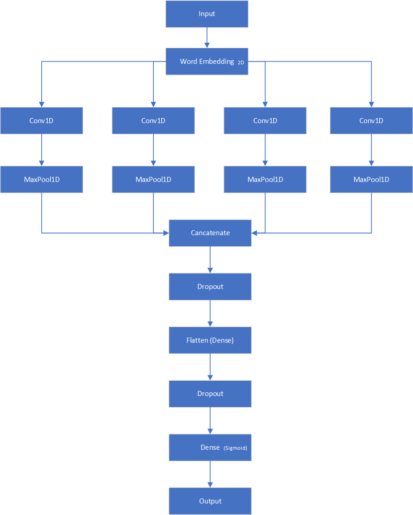

## Prepare the Data Set

```python
# One Hot Encoding for hcs
tmp_level = cf[['level']]

tmp_level = pd.get_dummies(tmp_level, columns=['level'], prefix=['level'])

tmp_level.head()
```

|  | level_0 | level_1 | level_2 | level_3 |
| --- | --- | --- | --- | --- |
| 0 | 1 | 0 | 0 | 0 |
| 1 | 1 | 0 | 0 | 0 |
| 2 | 0 | 0 | 0 | 1 |
| 3 | 1 | 0 | 0 | 0 |
| 4 | 0 | 0 | 0 | 1 |

```python
# Concatenate two data sets into one
final_df = pd.concat([cf, tmp_level], axis=1)
final_df.head()
```

## Data Splits for Training and Testing

```python
data_train, data_test = train_test_split(final_df, test_size=0.20, random_state=42)
data_train.shape
data_test.shape
```

```
(1764, 10)
```

```
(442, 10)
```

## Word Embedding Layer Setup

```python
MAX_SEQUENCE_LENGTH = 100
EMBEDDING_DIM = 300
all_training_words = [word for tokens in data_train["job_description"] for word in tokens]
TRAINING_VOCAB = sorted(list(set(all_training_words)))
label_names = ['level_0', 'level_1','level_2','level_3']
```

```python
tokenizer = Tokenizer(num_words=len(TRAINING_VOCAB), lower=True, char_level=False)
tokenizer.fit_on_texts(data_train["job_description"].tolist())
training_sequences = tokenizer.texts_to_sequences(data_train["job_description"].tolist())

train_word_index = tokenizer.word_index
print('Found %s unique tokens.' % len(train_word_index))
```

```
Found 10473 unique tokens.
```

```python
train_cnn_data = pad_sequences(training_sequences, maxlen=MAX_SEQUENCE_LENGTH)
```

```python
train_embedding_weights = np.zeros((len(train_word_index)+1, EMBEDDING_DIM))
for word,index in train_word_index.items():
    train_embedding_weights[index,:] = model_w2v[word] if word in model_w2v else np.random.rand(EMBEDDING_DIM)
print(train_embedding_weights.shape)
```

```
(10474, 300)
```

```python
test_sequences = tokenizer.texts_to_sequences(data_test["job_description"].tolist())
test_cnn_data = pad_sequences(test_sequences, maxlen=MAX_SEQUENCE_LENGTH)
```

## Define CNN Model

```python
# This function will define CNN model to include embedding, convolution, maxpooling, dropout and final dense layers
def ConvNet(embeddings, max_sequence_length, num_words, embedding_dim, labels_index):
    # setup input
    sequence_input = Input(shape=(max_sequence_length,), dtype='int32')
    # embedding layer by using pre-trained word2vec model
    embedding_layer = Embedding(num_words,embedding_dim,weights=[embeddings],input_length=max_sequence_length,trainable=False)
    # link input and embedding layers
    embedded_sequences = embedding_layer(sequence_input)
    # convolutional layers: four 1D convolutional layers to filter/extract different patterns
    convs = []
    filter_sizes = [2,3,4,5,6]

    for filter_size in filter_sizes:
        l_conv = Conv1D(filters=200, kernel_size=filter_size, activation='relu')(embedded_sequences)
        # setup max pooling layer after convolutional layer
        l_pool = GlobalMaxPooling1D()(l_conv)
        # link convolutional layer with max pooling layer
        convs.append(l_pool)

    # combine all four pattern outputs
    l_merge = concatenate(convs, axis=1)
    # add dropout layer for regularization
    x = Dropout(0.1)(l_merge)
    x = Dense(128, activation='relu')(x)
    # add another dropout layer for regularization
    x = Dropout(0.2)(x)
    preds = Dense(labels_index, activation='sigmoid')(x)
    # create/establish the model from inputs and outputs
    model = Model(sequence_input, preds)
    # compile model with loss function, optimizer and metrics setup
    model.compile(loss='binary_crossentropy',optimizer='adam',metrics=['acc'])
    # print summary info of the model
    model.summary()
    return model
```

```python
model = ConvNet(train_embedding_weights, MAX_SEQUENCE_LENGTH, len(train_word_index)+1, EMBEDDING_DIM, len(list(label_names)))
```

```
Model: "model_1"
__________________________________________________________________________________________________
Layer (type)                    Output Shape         Param #     Connected to
==================================================================================================
input_3 (InputLayer)            [(None, 100)]        0
__________________________________________________________________________________________________
embedding_2 (Embedding)         (None, 100, 300)     3142200     input_3[0][0]
__________________________________________________________________________________________________
conv1d_10 (Conv1D)              (None, 99, 200)      120200      embedding_2[0][0]
__________________________________________________________________________________________________
conv1d_11 (Conv1D)              (None, 98, 200)      180200      embedding_2[0][0]
__________________________________________________________________________________________________
conv1d_12 (Conv1D)              (None, 97, 200)      240200      embedding_2[0][0]
__________________________________________________________________________________________________
conv1d_13 (Conv1D)              (None, 96, 200)      300200      embedding_2[0][0]
__________________________________________________________________________________________________
conv1d_14 (Conv1D)              (None, 95, 200)      360200      embedding_2[0][0]
__________________________________________________________________________________________________
global_max_pooling1d_10 (Global (None, 200)          0           conv1d_10[0][0]
__________________________________________________________________________________________________
global_max_pooling1d_11 (Global (None, 200)          0           conv1d_11[0][0]
__________________________________________________________________________________________________
global_max_pooling1d_12 (Global (None, 200)          0           conv1d_12[0][0]
__________________________________________________________________________________________________
global_max_pooling1d_13 (Global (None, 200)          0           conv1d_13[0][0]
__________________________________________________________________________________________________
global_max_pooling1d_14 (Global (None, 200)          0           conv1d_14[0][0]
__________________________________________________________________________________________________
concatenate_2 (Concatenate)     (None, 1000)         0           global_max_pooling1d_10[0][0]
                                                                 global_max_pooling1d_11[0][0]
                                                                 global_max_pooling1d_12[0][0]
                                                                 global_max_pooling1d_13[0][0]
                                                                 global_max_pooling1d_14[0][0]
__________________________________________________________________________________________________
dropout_4 (Dropout)             (None, 1000)         0           concatenate_2[0][0]
__________________________________________________________________________________________________
dense_4 (Dense)                 (None, 128)          128128      dropout_4[0][0]
__________________________________________________________________________________________________
dropout_5 (Dropout)             (None, 128)          0           dense_4[0][0]
__________________________________________________________________________________________________
dense_5 (Dense)                 (None, 4)            516         dropout_5[0][0]
==================================================================================================
Total params: 4,471,844
Trainable params: 1,329,644
Non-trainable params: 3,142,200
__________________________________________________________________________________________________
```

## Training Model

```python
num_epochs = 20
batch_size = 34
```

```python
y_train = data_train[label_names].values
x_train = train_cnn_data
```

```python
x_train.shape
y_train.shape
```

```
(1764, 100)
```

```
(1764, 4)
```

```python
hist = model.fit(x_train, y_train, epochs=num_epochs, validation_split=0.1, shuffle=True, batch_size=batch_size)
```

```
Train on 1587 samples, validate on 177 samples
```

## Testing Model

```python
y_test = data_test[label_names].values
x_test = test_cnn_data
```

```python
loss, acc = model.evaluate(x_test,  y_test, verbose=2)
print("Test data, accuracy: {:5.2f}%".format(100*acc))
```

```
442/442 - 1s - loss: 0.6914 - acc: 0.8546
Test data, accuracy: 85.46%
```

```python
loss, acc = model.evaluate(x_train,  y_train, verbose=2)
print("Trained model, accuracy: {:5.2f}%".format(100*acc))
```

```
1764/1764 - 4s - loss: 0.0848 - acc: 0.9807
Trained model, accuracy: 98.07%
```

## Model Persistence

```python
model.save('./cnn_level.h5')
```

```python
# Recreate the exact same model, including its weights and the optimizer
new_model = load_model('./cnn_level.h5')
loss, acc = new_model.evaluate(x_train,  y_train, verbose=2)
print("Accuracy on training data set: {:5.2f}%".format(100*acc))
```

```
1764/1764 - 4s - loss: 0.0848 - acc: 0.9807
Accuracy on training data set: 98.07%
```

## Create a Graph of Accuracy and Loss Over Time

`model.fit()` returns a `History` object that contains a dictionary with everything that happened during training:

```
dict_keys(['loss', 'acc', 'val_loss', 'val_acc'])
```

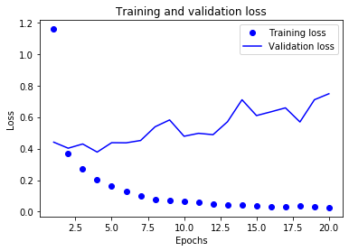

```python
import matplotlib.pyplot as plt

history_dict = hist.history
history_dict.keys()

acc = history_dict['acc']
val_acc = history_dict['val_acc']
loss = history_dict['loss']
val_loss = history_dict['val_loss']

epochs = range(1, len(acc) + 1)

# "bo" is for "blue dot"
plt.plot(epochs, loss, 'bo', label='Training loss')
# b is for "solid blue line"
plt.plot(epochs, val_loss, 'b', label='Validation loss')
plt.title('Training and validation loss')
plt.xlabel('Epochs')
plt.ylabel('Loss')
plt.legend()

plt.show()
```

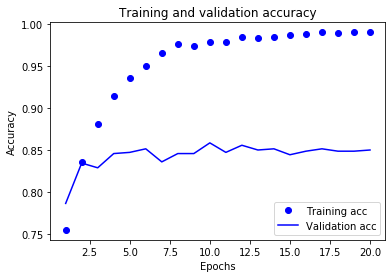

```python
plt.clf()   # clear figure

plt.plot(epochs, acc, 'bo', label='Training acc')
plt.plot(epochs, val_acc, 'b', label='Validation acc')
plt.title('Training and validation accuracy')
plt.xlabel('Epochs')
plt.ylabel('Accuracy')
plt.legend()

plt.show()
```

The dots represent the training loss and accuracy, and the solid lines are the validation loss and accuracy.

# Summary

In this notebook, I demonstrated the two approaches to do level analytics with job descriptions with scikit-learn and tensorflow frameworks. Based on the model evaluation of accuracy, the convolutional neural network can have better classification accuracy.

Actually, bother approaches (DNN & CNN) in this case produce over-fitting. It can be solved by adding more data for the training. Note: the CNN approach is better on over-fitting since I added more dropout and max pooling layers for regularization.